# Assignment_4

Shritej Chavan (BE14B004)

October 12, 2018

### Q.1 Discrete Time Fourier Series

1. $$x[k] = 4sin\left(\frac{\pi(k-2)}{3}\right)$$

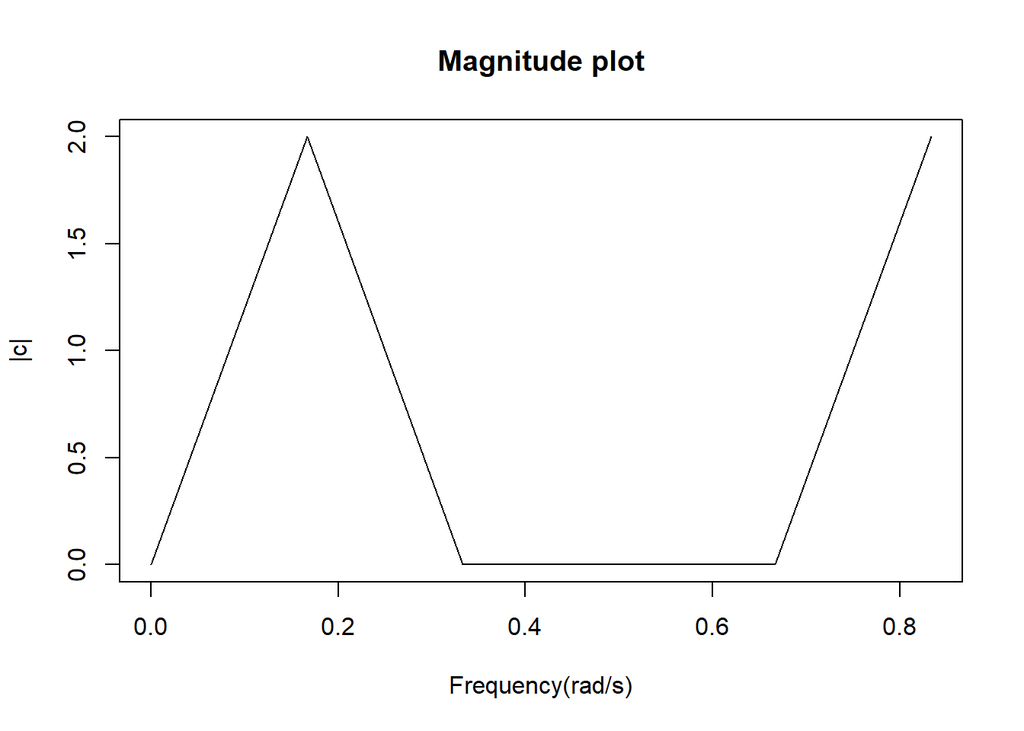

```r
Np = 6 # Fundamental time period
k = seq(0,Np)
x = 4*sin(pi*(k-2)/3)
c = rep ( 0 ,Np) #Intialise to zeros
for (h in 1 :Np) {
  for (h1 in 1 :Np) {
    c[h] = c[h] + (x[h1]*exp(-1i*2*pi*(h1-1)*(h-1)/Np))
  }
  c[h] = c[h]/Np
}
plot(seq(0 ,1-(1/Np),1/Np),abs(c),type="l",main = "Magnitude plot", xlab = "Frequency(rad/s)", ylab = "|c|")
```

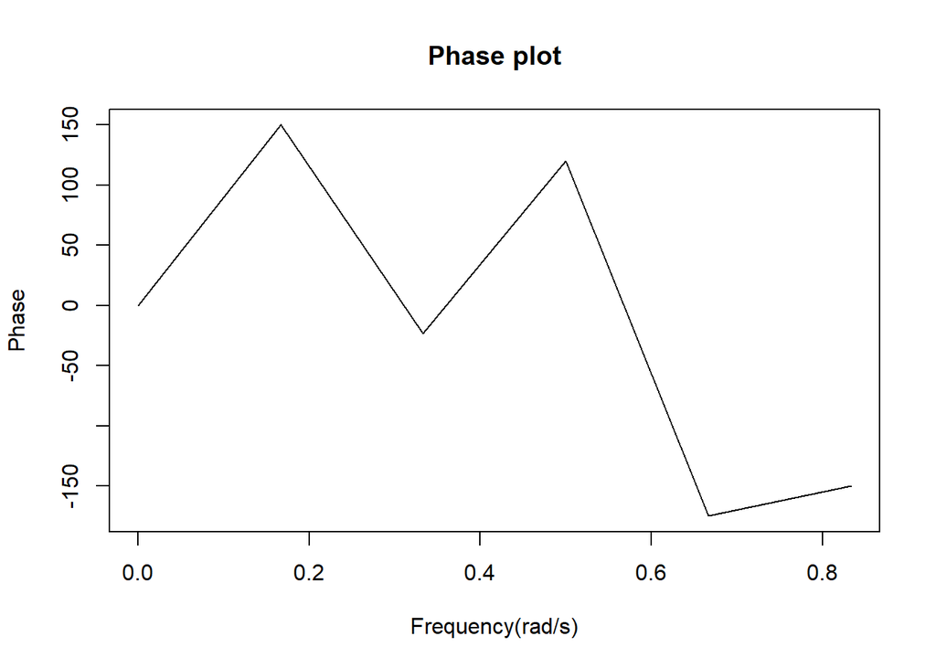

```r
frame()
plot(seq(0,1-(1/Np), 1/Np), Arg(c)*180/pi, type = "l", main = "Phase plot", xlab = "Frequency(rad/s)", ylab = "Phase")
```

2. $$x[k] = cos\left(\frac{2\pi}{3}k\right) + sin\left(\frac{2\pi}{5}k\right)$$
   The above signal has fundamental period of 15 samples. The fourier coefficients of the signal are given by

$$c_n = \frac{1}{15}\sum_{k=0}^{14}x[k]exp(-2j\omega n k)$$

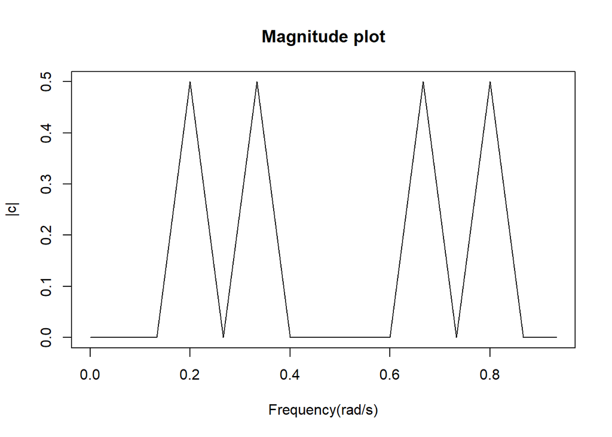

```r
Np = 15 # Fundamental time period
k = seq(0,Np)
x = cos(2*pi*k/3) + sin(2*pi*k/5)
c = rep ( 0 ,Np) #Intialise to zeros
for (h in 1 :Np) {
  for (h1 in 1 :Np) {
    c[h] = c[h] + (x[h1]*exp(-1i*2*pi*(h1-1)*(h-1)/Np))
  }
  c[h] = c[h]/Np
}
plot(seq(0 ,1-(1/Np),1/Np),abs(c),type="l",main = "Magnitude plot", xlab = "Frequency(rad/s)", ylab = "|c|")
```

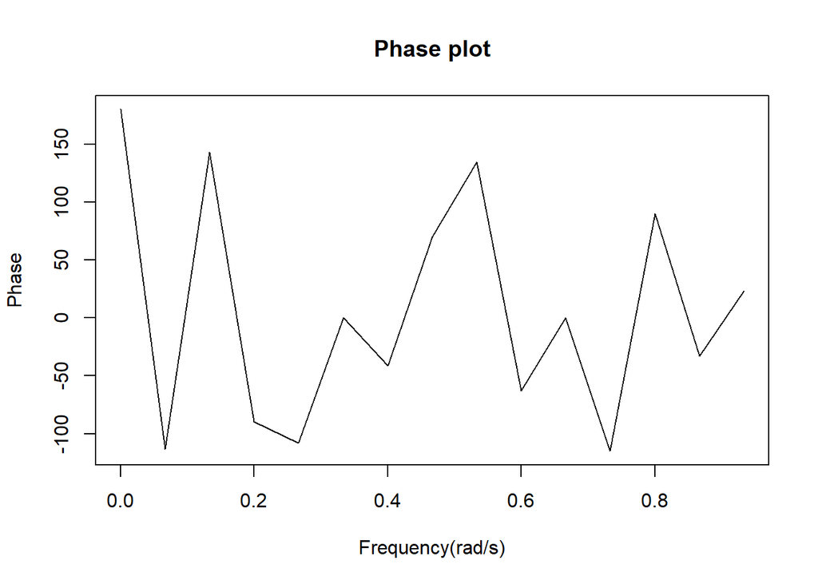

```r
frame()
plot(seq(0,1-(1/Np), 1/Np), Arg(c)*180/pi, type = "l", main = "Phase plot", xlab = "Frequency(rad/s)", ylab = "Phase")
```

3. $$x[k] = cos\left(\frac{2\pi}{3}k\right)sin\left(\frac{2\pi}{5}k\right)$$
   Therefore,

$$x[k] = 0.5\left(sin(\frac{16\pi}{15}k) - sin(\frac{4\pi}{15}k)\right)$$

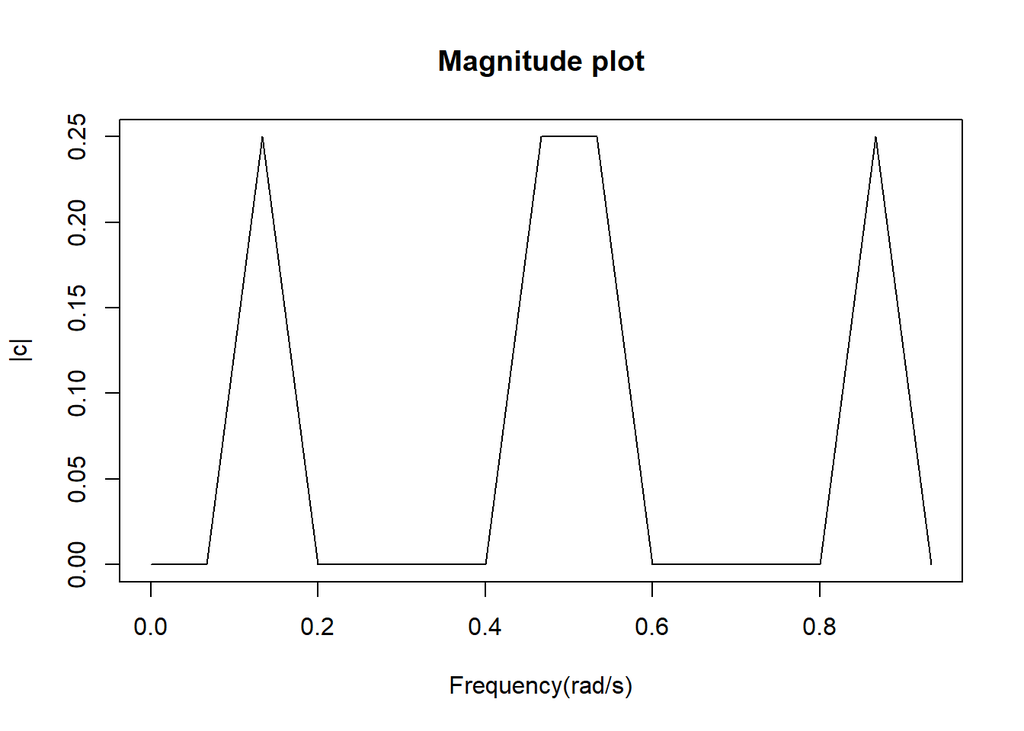

```r
Np = 15 # Fundamental time period
k = seq(0,Np)
x = 0.5*(sin(16*pi*k/15)- sin(4*pi*k/15))
c = rep ( 0 ,Np) #Intialise to zeros
for (h in 1 :Np) {
  for (h1 in 1 :Np) {
    c[h] = c[h] + (x[h1]*exp(-1i*2*pi*(h1-1)*(h-1)/Np))
  }
  c[h] = c[h]/Np
}
plot(seq(0 ,1-(1/Np),1/Np),abs(c),type="l", main = "Magnitude plot", xlab = "Frequency(rad/s)", ylab = "|c|")
```

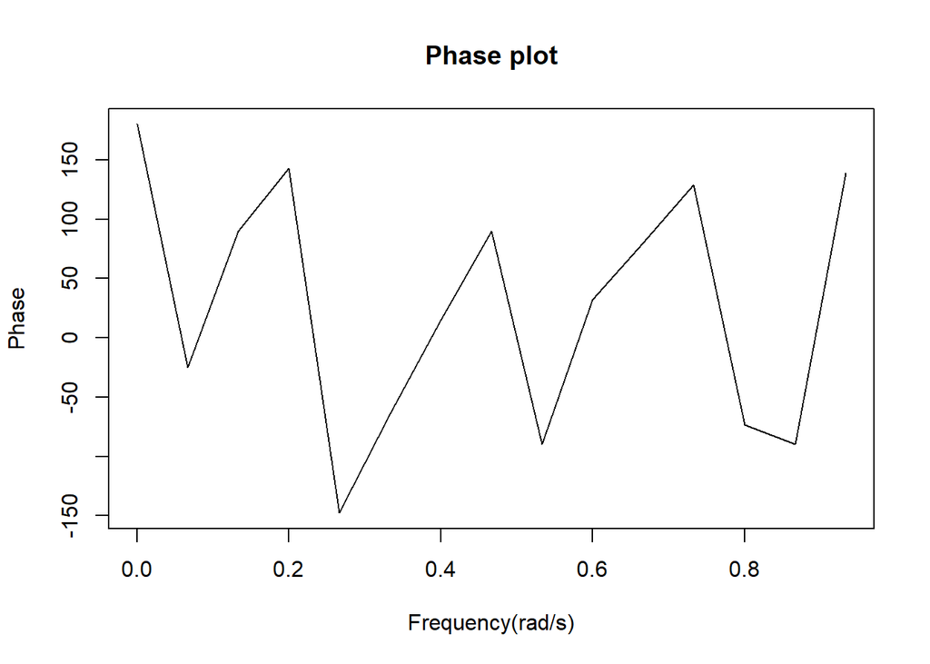

```r
frame()
plot(seq(0,1-(1/Np), 1/Np), Arg(c)*180/pi, type = "l", main = "Phase plot", xlab = "Frequency(rad/s)", ylab = "Phase")
```

2. $$c_n= cos\left(\frac{\pi n}{4}\right) + sin\left(\frac{3\pi n}{4}\right)$$

The fundamental period Np is 8 samples. The series $x[k]$ is given by

3. Periodic Signal $x[k] = {1,0,1,2,3,2}

The Parseval’s identity for a periodic signal is given by

$$\sum_{k=0}^{N-1}|x[k]|^2 = \frac{1}{N}\sum_{k=0}^{N-1}|C_n|^2$$
where $X[n]$ is Fourier coefficient of $x[k]$. Substituting given series in the equation, we get

$$\sum_{k=0}^5 |x[k]|^2 = 19$$
and

$$\frac{1}{6}\sum_{n=0}^{5}|X[n]|^2 = 19$$

Hence, Parseval’s identity has been proved.

### Q.2 Fourier Transform and FRF

2. X(0)

$$X(0) = \sum_{k=-\infty}^{\infty} x[k]$$
$$X(0) = \sum_{k=-2}^{2}x[k] = -1$$

2. $$\int_{-\pi}^{\pi} X(\omega) e^{-2j\omega} d\omega = x[-2] = -1$$
3. $X(\pi)$

$$X(\omega) = \sum_{k = -\infty}^{\infty}x[k]cos(\omega k)$$
Since the sequence is even imaginary terms cancel out

$$X(\pi) = \sum_{k=-\infty}^{\infty} (-1)^k x[k] = -9$$

$$\int_{-\infty}^{\infty}|X(\omega)|^2 d \omega = 2\pi \sum_{k = -\infty}^{\infty} |x[k]|^2 = 38\pi$$

2. $$y[k] - 1.4y[k-1] + 0.45y[k-2] = u[k] + 0.5u[k-1]$$

$$G(z^{-1}) = \frac{1 + 0.5z^{-1}}{1 - 1.4z^{-1} + 0.45z^{-2}}$$
Frequency response function:

$$G(\omega) = \frac{1 + 0.5e^{-j\omega}}{1 - 1.4e^{-j\omega} + 0.45e^{-2j\omega}}$$
c)

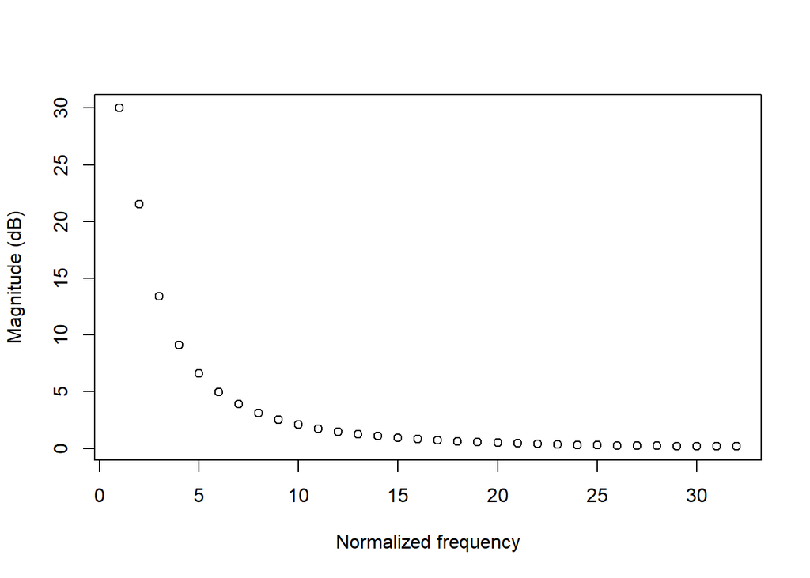

```r
frf = function(x)(1 + 0.5*exp(-1i*x))/(1 - 1.4*exp(-1i*x) + 0.45*exp(-2i*x))
x = seq(from = 0, to = pi, by = 0.1)
plot(abs(frf(x)), ylab = "Magnitude (dB)", xlab = "Normalized frequency")
```

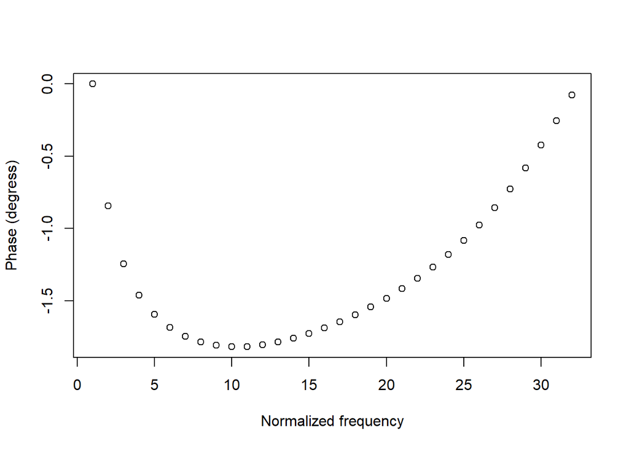

```r
plot(Arg(frf(x)), ylab = "Phase (degress)", xlab = "Normalized frequency")
```

From the above plots, we can conclude that it is a low pass filter.